# Petrology Research

Dylan Bryant

2024-12-02

[Home](https://bryantdylan.github.io/)

## Deformation-enhanced Diffusive Loss of Titanium in Quartz During Greenschist-facies Crystal-plastic Deformation, Wasatch Fault Zone, Utah.

### Research Question:

Investigate the diffusion of titanium in Quartz grains from deformed mylonite from the Wasatch Fault zone to better understand the timescales and temperatures at which deformation processes occur.

### INTRODUCTION

Two sample were used for this project, one is a granitic sample from the Little Cottonwood Stock, an intrusive igneous body, the other is a mylonitic rock from the Wasatch Fault Shear zone taken near Alta, Utah.

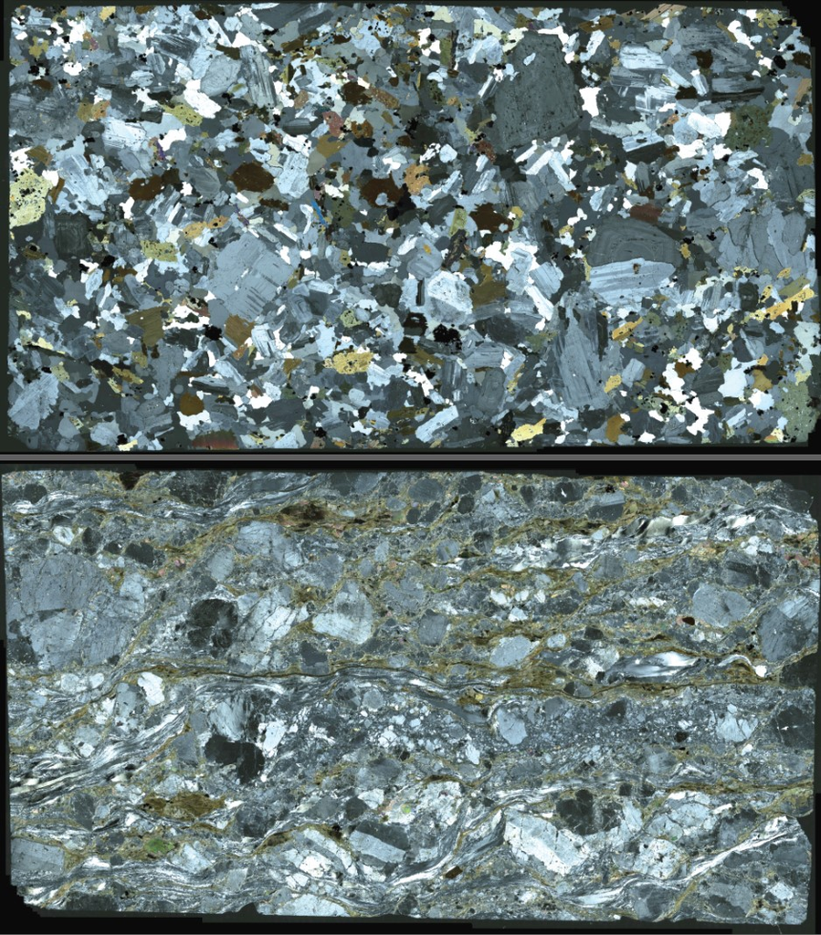

[interactive chart not shown]

Cartoonized location map of the sample locations

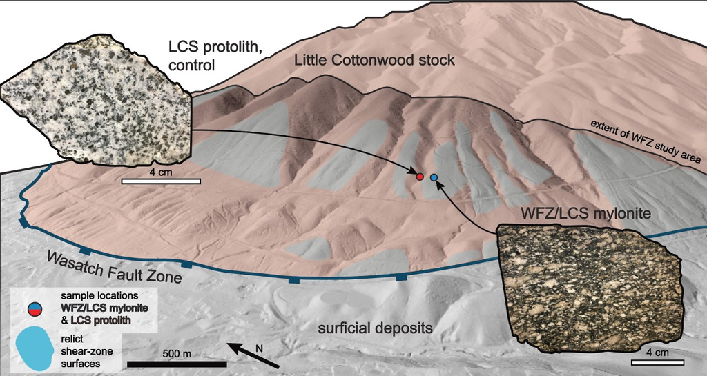

(Stearns et. al 2020)

### METHODS

Cathodoluminescence (CL) images were taken on a scanning electron microsope of quartz grains and used to verify if CL brightness could be used as a proxy for titanium concentrations.

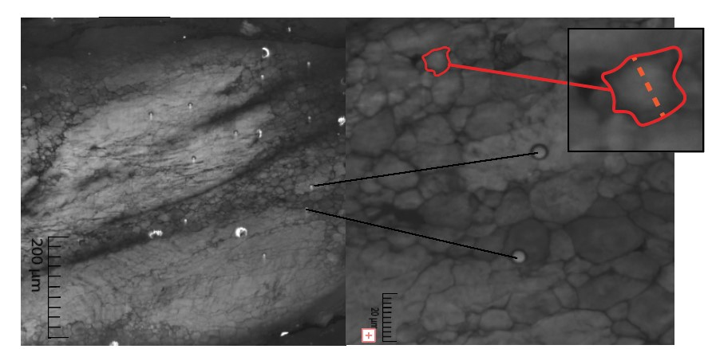

CL image of the mylonitic sample at different scale. Red outline shows a single grain with a grayscale profile extraction.

Five grayscale profiles were extracted from the protolith sample and calibrated with the measured Titanium to verify that the grayscales can act as a proxy for titanium concentrations to be used in diffusion modeling.

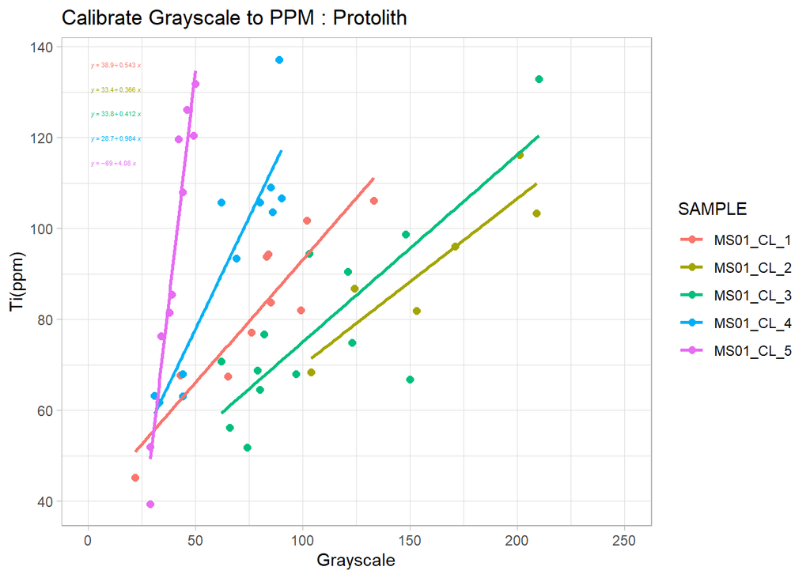

Once it was verified that the CL brightness could be used as a proxy for titanium concentrations, the diffusion temperatures could be approximated using the Arrhenius equation.

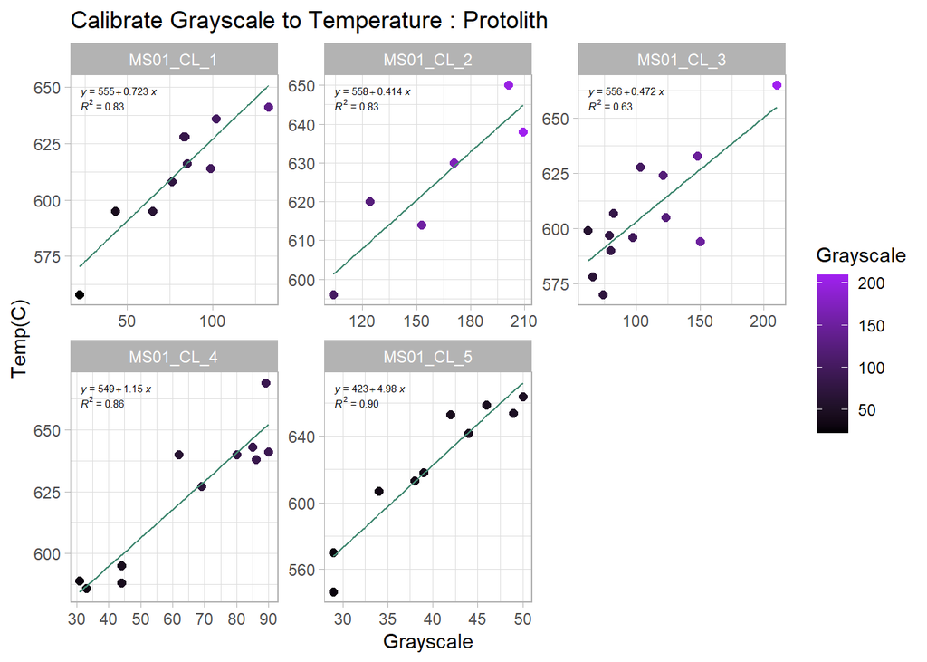

### Results

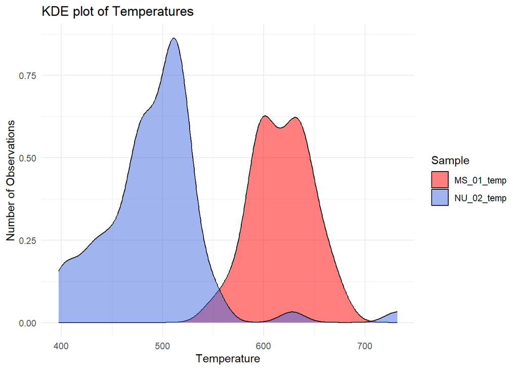

The kernel density plot shows that the temperatures of the titanium in the protolith and the mylonite are around 620 and 510 degrees celsius.

This data provides a means to model diffusion profiles for the mylonite, assuming isothermal conditions, in order to understand the time scales at which the diffusion of titanium in quartz was happening during the crystal-plastic enhanced green-schist facies ductile deformation in the shear zone of the Wasatch Fault.